# Regression

Platon

25 02 2020

## Начало

Загрузим нужные библиотеки! leaps и RcmdrMisc пригодятся нам для оценки наших моделей

```r
library(ggplot2)
library(MASS)
library(plyr)
library(leaps)
library(RcmdrMisc)
library(gvlma)
```

## Немного математики

Попытаемся понять, как устроена модель и сделаем свою функцию регрессии. Возьмем датасет diamonds из библиотеки ggplot2

```r
data=diamonds
head(data, 8)
```

```
## # A tibble: 8 x 10
##   carat cut       color clarity depth table price     x     y     z
##   <dbl> <ord>     <ord> <ord>   <dbl> <dbl> <int> <dbl> <dbl> <dbl>
## 1 0.23  Ideal     E     SI2      61.5    55   326  3.95  3.98  2.43
## 2 0.21  Premium   E     SI1      59.8    61   326  3.89  3.84  2.31
## 3 0.23  Good      E     VS1      56.9    65   327  4.05  4.07  2.31
## 4 0.290 Premium   I     VS2      62.4    58   334  4.2   4.23  2.63
## 5 0.31  Good      J     SI2      63.3    58   335  4.34  4.35  2.75
## 6 0.24  Very Good J     VVS2     62.8    57   336  3.94  3.96  2.48
## 7 0.24  Very Good I     VVS1     62.3    57   336  3.95  3.98  2.47
## 8 0.26  Very Good H     SI1      61.9    55   337  4.07  4.11  2.53
```

Создадим переменные с нужными данными:

```r
# число наблюдений
N=nrow(data)
# средние и sd независимой и зависимой переменной
X=data$depth
Y=data$price
X_mean=mean(X)
X_sd=sd(X)

Y_mean=mean(Y)
Y_sd=sd(Y)

XY_mean=mean(X*Y)

XY_cov=sum((X-X_mean)*(Y-Y_mean))/(N-1)
r_coef=XY_cov/(X_sd*Y_sd)
```

Теперь мы можем найти коэффициенты нашей модели

**intercept** отвечает за расстояние нашей прямой от оси Х, а **slope** определяет наклон прямой

```r
Slope=r_coef*(Y_sd/X_sd)
Intercept=Y_mean - Slope*X_mean
result=paste0('Regression formula: ', round(Slope,2), 'x', '+', round(Intercept,2)); result
```

```
## [1] "Regression formula: -29.65x+5763.67"
```

Ну не писать же нам это все каждый раз! Сделаем простую функцию для регрессии:

```r
reg_function=function(x, y){
  N=length(x)

  X_mean=mean(x)
  X_sd=sd(x)

  Y_mean=mean(y)
  Y_sd=sd(y)

  XY_mean=mean(x*y)

  XY_cov=sum((x-X_mean)*(y-Y_mean))/(N-1)
  r_coef=XY_cov/(X_sd*Y_sd)

  b=r_coef*(Y_sd/X_sd)
  a=Y_mean - b*X_mean
  if (a>0){
    sign=' + '
  } else {
    sign=''
  }

  res=paste0('Regression formula: ', b, 'x', sign, a)
  print(res)
  res_data=data.frame(x=x, y=y, y_calc=b*x+a)
  return(res_data)
}
```

Сравним ее итог с уже существующей функцией:

```r
model=lm(price~depth, data);model
```

```
##
## Call:
## lm(formula = price ~ depth, data = data)
##
## Coefficients:
## (Intercept)        depth
##     5763.67       -29.65
```

```r
res=reg_function(data$depth, data$price)
```

```
## [1] "Regression formula: -29.6499698822602x + 5763.66771727752"
```

Неплохо! Но как понять, насколько хорошо она описывает данные? Используем показатель **R-squared**, который сами же и посчитаем

```r
R_sq=function(x, y, y_calc){
  SS_tot=sum((y-mean(y))**2)
  SS_explained=sum((y_calc-mean(y))**2)
  SS_res=sum((y-y_calc)**2)
  R2=1-(SS_res/SS_tot)
  R2_adj=1-(SS_res/((length(x)-2))/(SS_tot/(length(x)-1)))
  print(paste0('R-squared is ', R2))
  print(paste0('adj. R-squared is ', R2_adj))
  return(R2)
}
our_R=R_sq(res$x, res$y, res$y_calc)
```

```
## [1] "R-squared is 0.00011336722437838"
## [1] "adj. R-squared is 9.48295212234163e-05"
```

```r
round(summary(lm(price~depth, data))$r.squared,2)
```

```
## [1] 0
```

В случае хороших моделей *R-squared* должен приближаться к 1. У нас … не очень хорошая модель Что же мы сделали не так?

## Требования к модели

Перед построением линейной модели необходимо учитывать несколько моментов:

1. **Линейность** зависимости. Посмотрим ее по графику

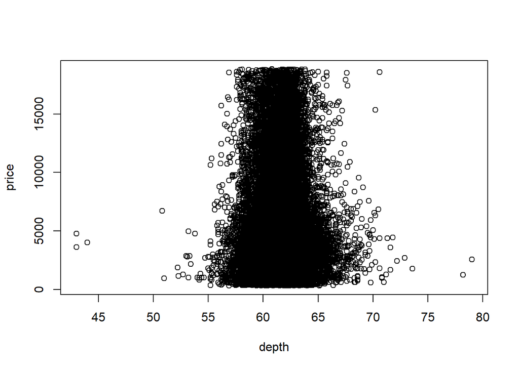

```r
plot(price~depth, data)
```

Уже сейчас видно, что линейная модель - не очень хорошая идея

2. **Нормальное** распределение переменных

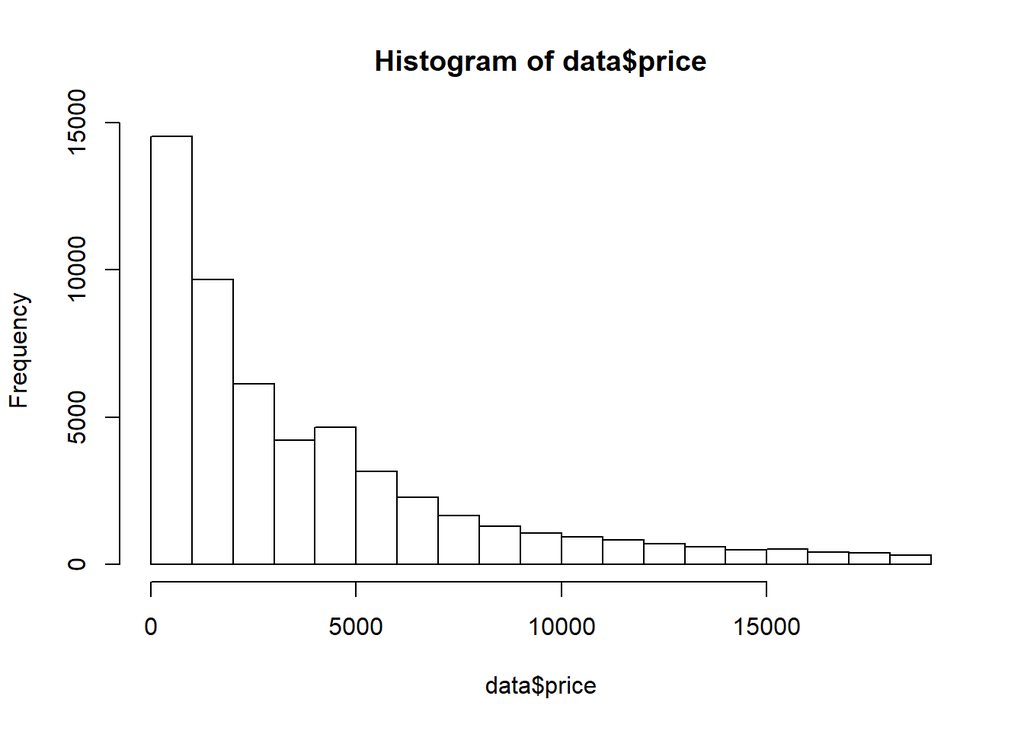

```r
hist(data$price)
```

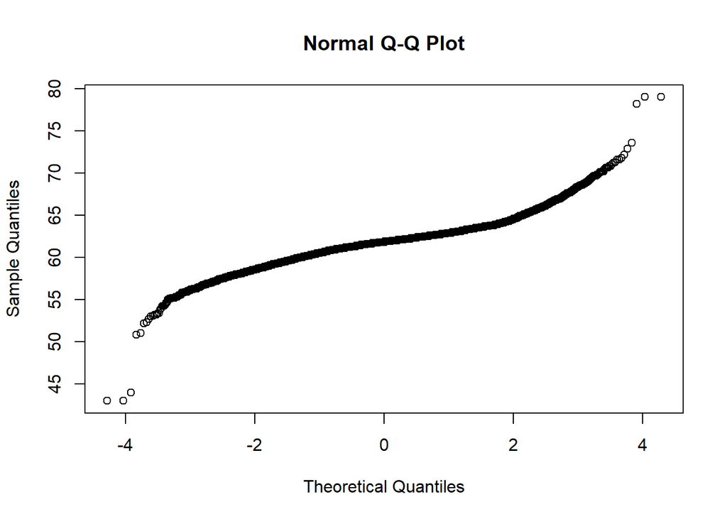

```r
qqnorm(data$depth)
```

3. **Мультиколлинеарность**. В нашем случае ее не может быть, а вот в случае нескольких предикторов - вполне Нужно смотреть корреляции между переменными. Если корреляция более 0.7-0.8 (по модулю) - переменные явно мультиколлинеарны.

Например, здесь переменные disp и mpg мультиколлинеарны

```r
cor(mtcars[,c('mpg', 'disp', 'drat')])
```

```
##             mpg       disp       drat
## mpg   1.0000000 -0.8475514  0.6811719
## disp -0.8475514  1.0000000 -0.7102139
## drat  0.6811719 -0.7102139  1.0000000
```

4. **Гомоскедастичность** остатков

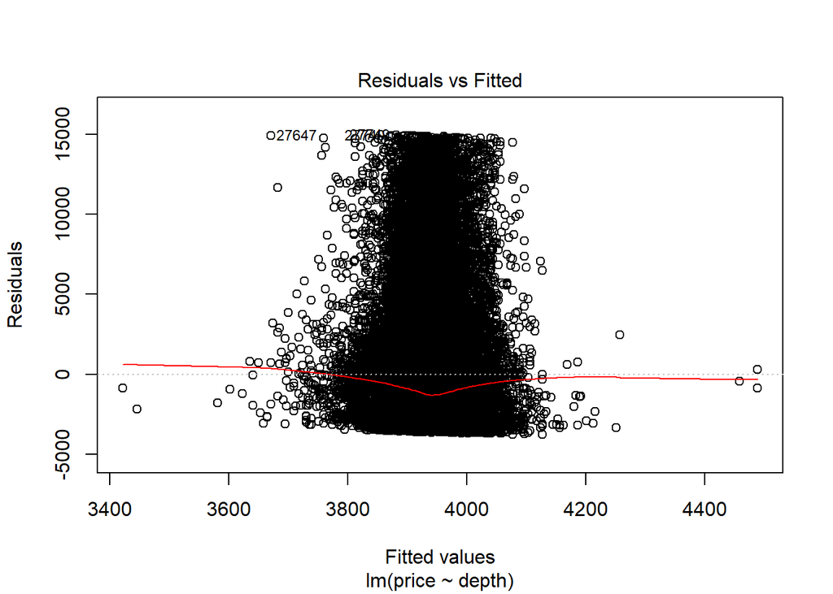

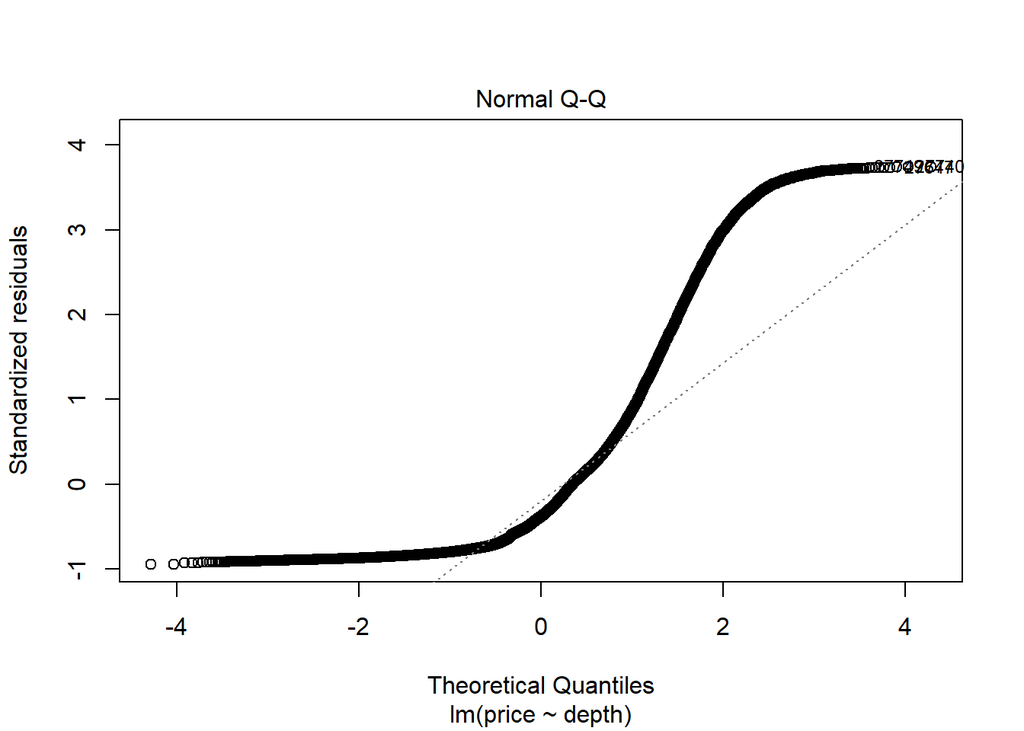

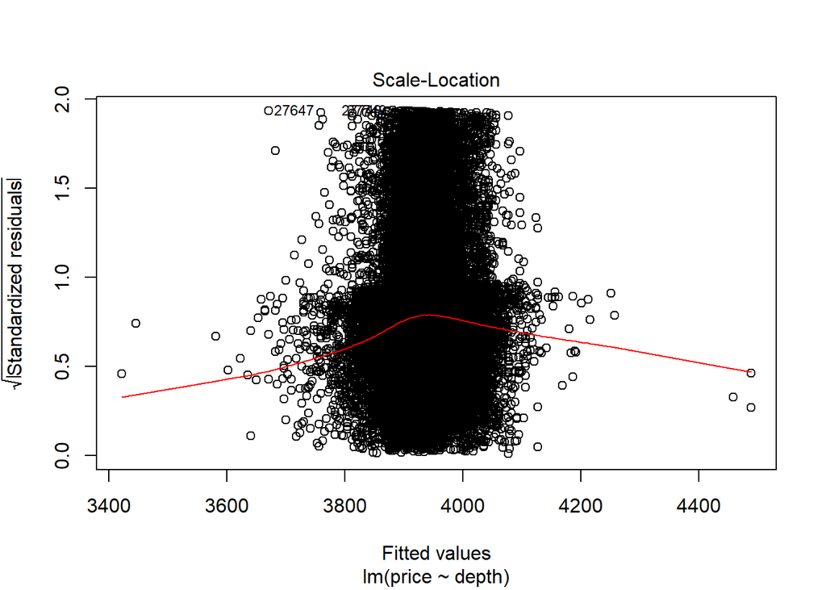

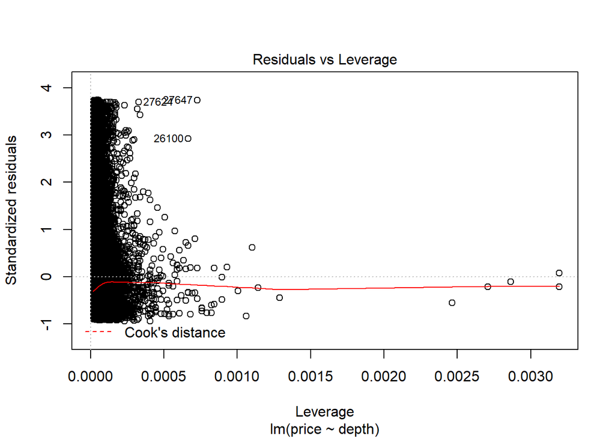

```r
plot(lm(price~depth, data))
```

5. Нормальное распределение остатков

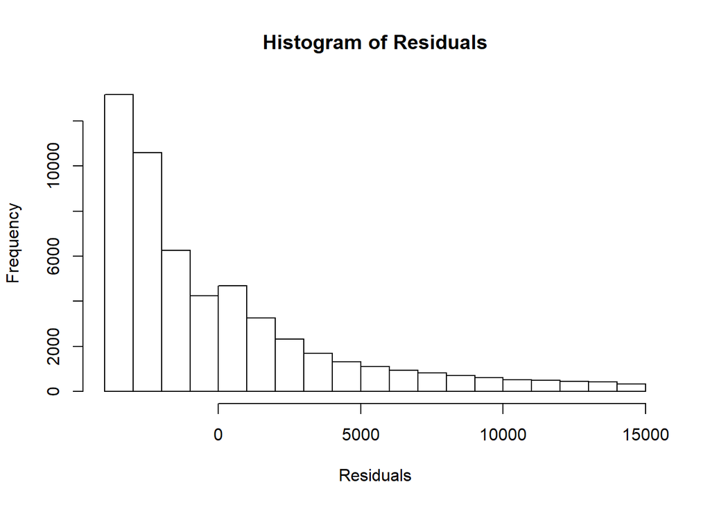

```r
Residuals=res$y-res$y_calc
hist(Residuals)
```

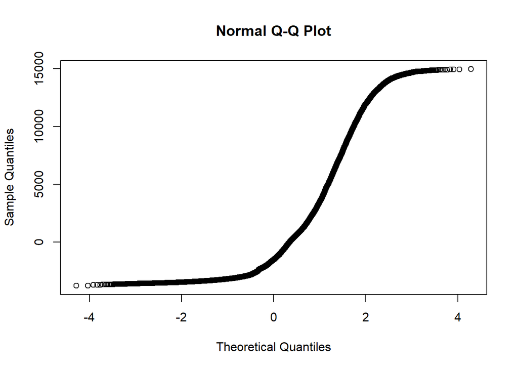

```r
qqnorm(Residuals)
```

Также можно использовать функцию gvlma из пакета gvlma

```r
gv_model=gvlma(model)

summary(gv_model)
```

```
##
## Call:
## lm(formula = price ~ depth, data = data)
##
## Residuals:
##    Min     1Q Median     3Q    Max
##  -3766  -2986  -1521   1396  14937
##
## Coefficients:
##             Estimate Std. Error t value Pr(>|t|)
## (Intercept)  5763.67     740.56   7.783 7.21e-15 ***
## depth         -29.65      11.99  -2.473   0.0134 *
## ---
## Signif. codes:  0 '***' 0.001 '**' 0.01 '*' 0.05 '.' 0.1 ' ' 1
##
## Residual standard error: 3989 on 53938 degrees of freedom
## Multiple R-squared:  0.0001134,  Adjusted R-squared:  9.483e-05
## F-statistic: 6.115 on 1 and 53938 DF,  p-value: 0.0134
##
##
## ASSESSMENT OF THE LINEAR MODEL ASSUMPTIONS
## USING THE GLOBAL TEST ON 4 DEGREES-OF-FREEDOM:
## Level of Significance =  0.05
##
## Call:
##  gvlma(x = model)
##
##                        Value   p-value                   Decision
## Global Stat        34161.157 0.000e+00 Assumptions NOT satisfied!
## Skewness           23504.826 0.000e+00 Assumptions NOT satisfied!
## Kurtosis           10613.013 0.000e+00 Assumptions NOT satisfied!
## Link Function         40.481 1.985e-10 Assumptions NOT satisfied!
## Heteroscedasticity     2.837 9.213e-02    Assumptions acceptable.
```

Увы! С нашими данными все плохо. Линейная регрессия - не наш вариант :-(

## Визуализация модели

Дабы убедиться, что в нашем случае все плохо, давайте визуализируем модель

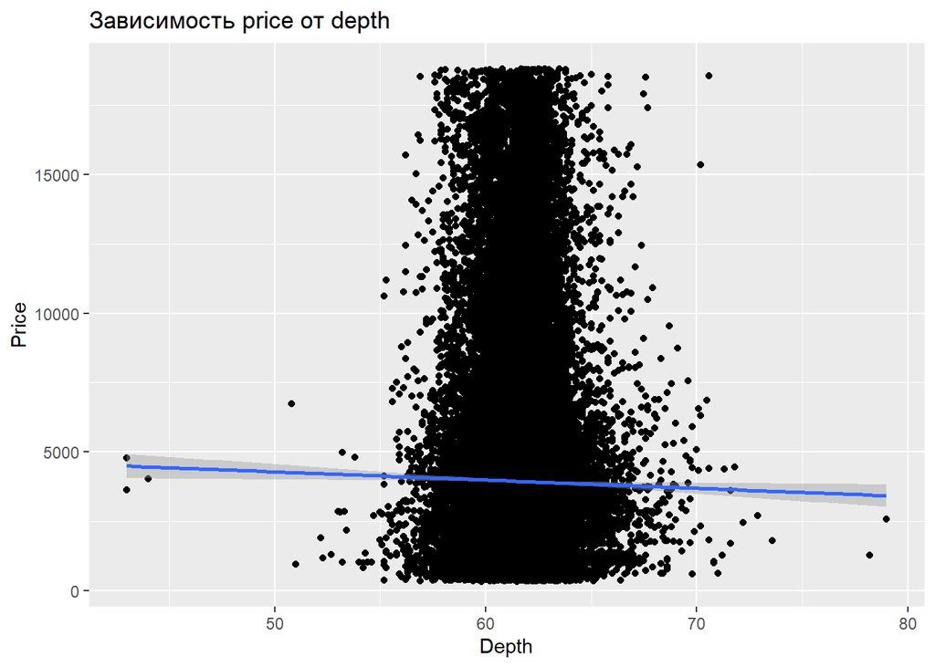

```r
ggplot(res, aes(x=x, y=y))+
  geom_point()+
  geom_smooth(method='lm')+
  ggtitle('Зависимость price от depth')+
  xlab('Depth')+ylab('Price')
```

Как видно по графику, модель очень плохо описывает наш “термитник”

## Номинативные предикторы

В нашей модели мы можем использовать номинативные предикторы после преобразования. Мы должны перевести их в так называемые *dummy*-переменные Функция lm делает это автоматически

```r
nom_var=as.factor(mtcars$am)
nom_var=revalue(nom_var, c("A"='0', "M"='1'))
nom_var=as.numeric(as.character(nom_var));nom_var
```

```
##  [1] 1 1 1 0 0 0 0 0 0 0 0 0 0 0 0 0 0 1 1 1 0 0 0 0 0 1 1 1 1 1 1 1
```

```r
new_data=data.frame(am=nom_var, disp=mtcars$disp, qsec=mtcars$qsec)

lm(qsec~am+disp, new_data)
```

```
##
## Call:
## lm(formula = qsec ~ am + disp, data = new_data)
##
## Coefficients:
## (Intercept)           am         disp
##    21.84942     -2.67723     -0.01263
```

```r
lm(qsec~am+disp, mtcars)
```

```
##
## Call:
## lm(formula = qsec ~ am + disp, data = mtcars)
##
## Coefficients:
## (Intercept)           am         disp
##    21.84942     -2.67723     -0.01263
```

## Функция lm

По дефолту вывод функции lm довольно беден. Однако с помощью *summary()* мы можем узнать больше информации

```r
our_model=lm(qsec~am+disp, mtcars); our_model
```

```
##
## Call:
## lm(formula = qsec ~ am + disp, data = mtcars)
##
## Coefficients:
## (Intercept)           am         disp
##    21.84942     -2.67723     -0.01263
```

```r
summary(our_model)
```

```
##
## Call:
## lm(formula = qsec ~ am + disp, data = mtcars)
##
## Residuals:
##     Min      1Q  Median      3Q     Max
## -2.0204 -0.8633 -0.2623  0.8749  2.8283
##
## Coefficients:
##              Estimate Std. Error t value Pr(>|t|)
## (Intercept) 21.849416   0.705117  30.987  < 2e-16 ***
## am          -2.677229   0.552115  -4.849 3.86e-05 ***
## disp        -0.012626   0.002223  -5.680 3.85e-06 ***
## ---
## Signif. codes:  0 '***' 0.001 '**' 0.01 '*' 0.05 '.' 0.1 ' ' 1
##
## Residual standard error: 1.237 on 29 degrees of freedom
## Multiple R-squared:  0.5516, Adjusted R-squared:  0.5207
## F-statistic: 17.84 on 2 and 29 DF,  p-value: 8.886e-06
```

Уже куда интереснее! Что же тут есть?

1. Оценки значений коэффициентов в колонке Estimate.
2. t-value и p-value - коэффициенты проверяются на значимость. Значимость удобно смотреть по звездочкам справа.
3. R-squared и adjasted R-squared. Ориентироваться лучше на второе, поскольку этот показатель надежнее
4. F-statistics. Она является показателем того, насколько модель отличается от intercept-only model. То есть просто от оценки среднего

Иногда нам надо не просто посмотреть, но и использовать данные из такого вывода в дальнейшем коде. Вытащим же их!

```r
our_model_summary=summary(our_model)
coefs_table=data.frame(our_model_summary$coefficients)
coefs=coefs_table$Estimate
# делаем именнованный вектор с коэффициентами
names(coefs)=rownames(coefs_table)
coefs
```

```
## (Intercept)          am        disp
## 21.84941562 -2.67722918 -0.01262577
```

```r
# делаем именнованный вектор с p-value коэффициентов
p_vals=round(coefs_table$Pr...t.., 2)
names(p_vals)=rownames(coefs_table)
p_vals
```

```
## (Intercept)          am        disp
##           0           0           0
```

```r
# достаем R-squared и adjasted R-squared
R_sqs=c(our_model_summary$r.squared, our_model_summary$adj.r.squared)
names(R_sqs)=c('r.squared', 'adj.r.squared')
R_sqs
```

```
##     r.squared adj.r.squared
##     0.5516313     0.5207093
```

```r
# смотрим остатки модели (например, для анализа качества модели)
residuals.lm(our_model)
```

```
##           Mazda RX4       Mazda RX4 Wag          Datsun 710      Hornet 4 Drive
##        -0.692063285        -0.132063285         0.801396689         0.848032972
##   Hornet Sportabout             Valiant          Duster 360           Merc 240D
##        -0.284138516         1.211382571        -1.464138516         0.002784801
##            Merc 230            Merc 280           Merc 280C          Merc 450SE
##         2.828292760        -1.433336611        -0.833336611        -0.967228327
##          Merc 450SL         Merc 450SLC  Cadillac Fleetwood Lincoln Continental
##        -0.767228327        -0.367228327         2.089947693         1.778438457
##   Chrysler Imperial            Fiat 128         Honda Civic      Toyota Corolla
##         1.125923062         1.291461636         0.303584327         1.625505787
##       Toyota Corona    Dodge Challenger         AMC Javelin          Camaro Z28
##        -0.323060674        -0.964420845        -0.711181621        -2.020396213
##    Pontiac Firebird           Fiat X1-9       Porsche 914-2        Lotus Europa
##         0.250892273         0.725249367        -0.953306343        -1.071475740
##      Ford Pantera L        Ferrari Dino       Maserati Bora          Volvo 142E
##        -0.240541267        -1.841449831        -0.771829753         0.955531696
```

```r
# значения зависимой переменной согласно модели
fitted(our_model)
```

```
##           Mazda RX4       Mazda RX4 Wag          Datsun 710      Hornet 4 Drive
##            17.15206            17.15206            17.80860            18.59197
##   Hornet Sportabout             Valiant          Duster 360           Merc 240D
##            17.30414            19.00862            17.30414            19.99722
##            Merc 230            Merc 280           Merc 280C          Merc 450SE
##            20.07171            19.73334            19.73334            18.36723
##          Merc 450SL         Merc 450SLC  Cadillac Fleetwood Lincoln Continental
##            18.36723            18.36723            15.89005            16.04156
##   Chrysler Imperial            Fiat 128         Honda Civic      Toyota Corolla
##            16.29408            18.17854            18.21642            18.27449
##       Toyota Corona    Dodge Challenger         AMC Javelin          Camaro Z28
##            20.33306            17.83442            18.01118            17.43040
##    Pontiac Firebird           Fiat X1-9       Porsche 914-2        Lotus Europa
##            16.79911            18.17475            17.65331            17.97148
##      Ford Pantera L        Ferrari Dino       Maserati Bora          Volvo 142E
##            14.74054            17.34145            15.37183            17.64447
```

## Выбор модели

Если мы не знаем, какие предикторы лучше включить и решаем довериться машине, то мы можем использовать stepwise алгоритм (это больше характерно для data science, чем для науки)

```r
full_model=lm(qsec~., mtcars)
best_AIC_model_both=step(full_model, direction = "both", trace = F)
summary(best_AIC_model_both)$r.squared
```

```
## [1] 0.8642928
```

```r
best_AIC_model_backward=step(full_model, direction = "backward", trace = F)
summary(best_AIC_model_backward)$r.squared
```

```
## [1] 0.8642928
```

```r
best_AIC_model_forward=step(full_model, direction = "forward", trace = F)
summary(best_AIC_model_forward)$r.squared
```

```
## [1] 0.8746926
```

```r
stepwise(full_model, direction = "backward", criterion = 'AIC', trace = F)
```

```
##
## Direction:  backward
## Criterion:  AIC
```

```
##
## Call:
## lm(formula = qsec ~ cyl + disp + wt + vs + am + carb, data = mtcars)
##
## Coefficients:
## (Intercept)          cyl         disp           wt           vs           am
##   18.611144    -0.369984    -0.008899     1.475086     0.968162    -0.902579
##        carb
##   -0.434722
```

```r
stepwise(full_model, direction = "backward", criterion = 'BIC', trace = F)
```

```
##
## Direction:  backward
## Criterion:  BIC
```

```
##
## Call:
## lm(formula = qsec ~ disp + wt + vs + carb, data = mtcars)
##
## Coefficients:
## (Intercept)         disp           wt           vs         carb
##    15.58497     -0.01229      1.89509      1.46947     -0.58323
```

## Предсказания

Мы можем использовать нашу модель для предсказания значений зависимой переменной

```r
model=lm(price~depth, diamonds)
new_x_values=data.frame(depth=1:10)
predict(model, new_x_values)
```

```
##        1        2        3        4        5        6        7        8
## 5734.018 5704.368 5674.718 5645.068 5615.418 5585.768 5556.118 5526.468
##        9       10
## 5496.818 5467.168
```

## Задание

Для выполнения задания нужен датасет с несколькими переменными

1. Для модели с одним предиктором

1.1) проверьте данные и модель на соответствие требованиям

1.2) визуализируйте модель

2. Для модели с несколькими предикторами

2.1) проверьте данные и модель на соответствие требованиям

2.2) с помощью stepwise алгоритма найдите лучшее(-ие) сочетание (-ия) предикторов

3*) Опираясь на функцию lm, создайте свою функцию, которая будет принимать переменную-предиктор (x) и зависимую переменную (y), строить линейную модель и выводить уравнение регрессии, показатели R-squared и adjusted R-squared